# ChIP Seq Annotation Script

Avantika Diwadkar (avantika.diwadkar@pennmedicine.upenn.edu)

This report carries out annotation and visualization of differentially bound peaks/sites identified by processing ChIP-Seq data from GEO study. The steps involved are:

- Distribution of peak counts across the TSS region
- Annotation of the enriched regions
- Visualization of differentially bound sites to compare distance from TSS, annotations and overlap

Input:

A pre-prepared output file with a GRanges object saved from running ChIP_Seq_Diff_Binding_Analysis.Rmd script.

The input columns should show:

- the mean read concentration over all the samples: the default calculation uses log2 normalized ChIP read counts with control read counts subtracted
- the mean concentration of the first (dex) group
- the mean concentration of second (control) group
- the Fold column shows the difference in mean concentrations between the two groups (Conc_dex - Conc_control): a positive value indicating increased binding affinity in the dex group and a negative value indicating increased binding affinity in the control group.
- a raw p-value: confidence measures for identifying these sites as differentially bound
- FDR: a multiple testing corrected FDR in the final column.

Outputs:

- Gene Annotation of the GRanges input file(s) (.bed/.txt)
- A ChIP-Seq annotation and visualization report (.html)

Manually change the variables for files (file1,file2) and conditions as well as txdb depending upon the genome used

Install the prerequisite R packages if they do not exist

- ChIPseeker
- TxDb.Hsapiens.UCSC.hg38.knownGene
- clusterProfiler
- org.Hs.eg.db
- dplyr and plyr
- pander

Loading the required libraries

#### PRE-ANNOTATION ANALYSIS AND VISUALIZATION

Read-in and view your input files

```
##   seqnames     start       end width strand width.1 strand.1 Conc Conc_dex
## 1    chr11 114179230 114179729   500      *     501        * 9.44    10.41
## 2    chr10  74056315  74056814   500      *     501        * 9.12    10.07
## 3     chr2  20438534  20439033   500      *     501        * 8.74     9.67
## 4    chr11 114154444 114154943   500      *     501        * 8.78     9.71
## 5    chr17  59825483  59825982   500      *     501        * 8.69     9.61
## 6    chr19  18020243  18020742   500      *     501        * 8.44     9.39
##   Conc_control Fold   p.value       FDR
## 1         4.71 5.70 4.03e-119 3.30e-114
## 2         5.38 4.68 4.03e-111 1.65e-106
## 3         5.38 4.29  8.74e-93  2.39e-88
## 4         5.30 4.42  1.69e-91  3.47e-87
## 5         5.51 4.10  7.51e-83  1.23e-78
## 6         4.63 4.75  2.73e-82  3.74e-78
```

```
##   seqnames     start       end width strand width.1 strand.1 Conc Conc_dex
## 1    chr20  47318228  47318727   500      *     501        * 7.90     8.68
## 2    chr16  56608382  56608881   500      *     501        * 9.18     9.77
## 3    chr22  30246400  30246899   500      *     501        * 7.38     5.81
## 4    chr17   8152093   8152592   500      *     501        * 6.81     7.59
## 5     chr6  35727586  35728085   500      *     501        * 6.13     7.02
## 6     chr9 129320809 129321308   500      *     501        * 7.58     8.25
##   Conc_control  Fold  p.value      FDR
## 1         6.07  2.61 2.05e-37 5.42e-33
## 2         8.15  1.61 4.01e-25 5.29e-21
## 3         8.11 -2.30 4.86e-24 4.28e-20
## 4         4.99  2.60 2.25e-19 1.49e-15
## 5         3.37  3.64 4.41e-19 2.33e-15
## 6         6.32  1.93 5.73e-18 2.52e-14
```

#### Distribution of peaks across all chromosomes in the genome

Thus, you can visualize peaks across all chromosomes for the different conditions and confirm the result with number of peaks calculated prior.

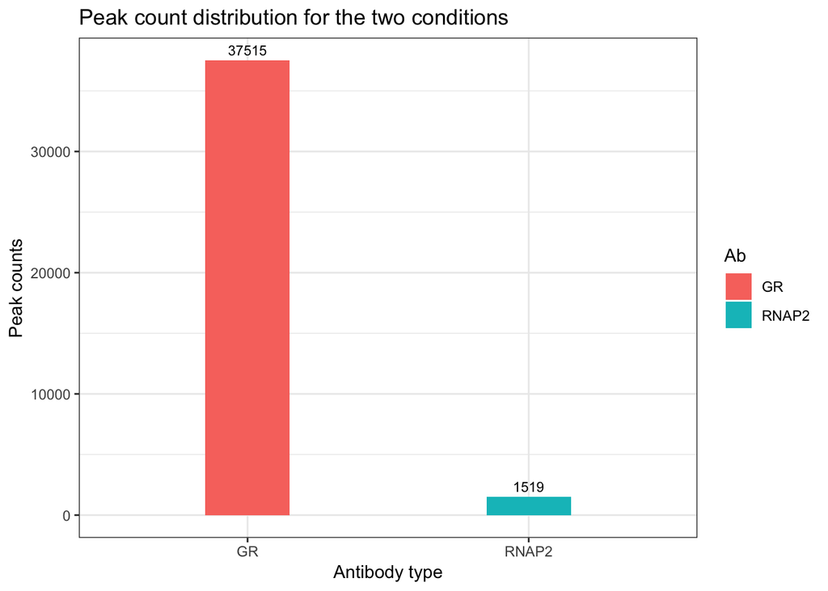

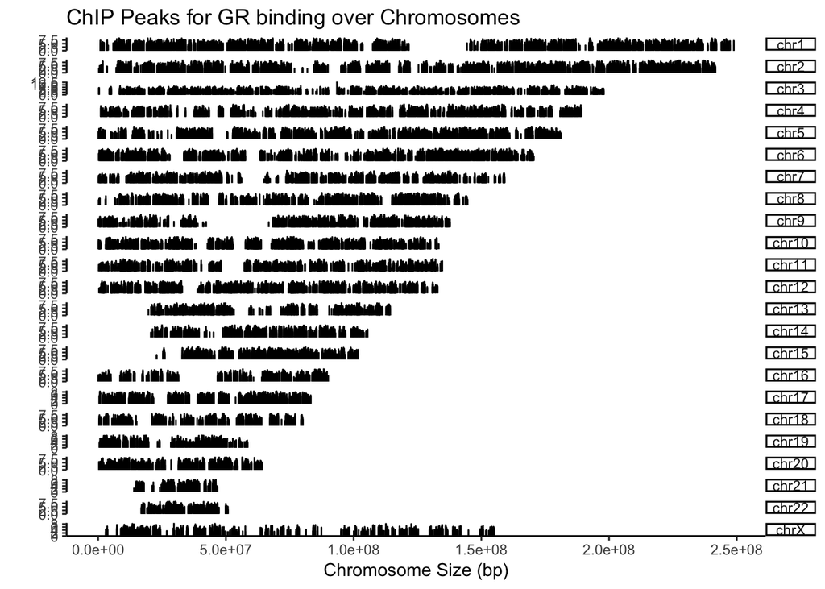

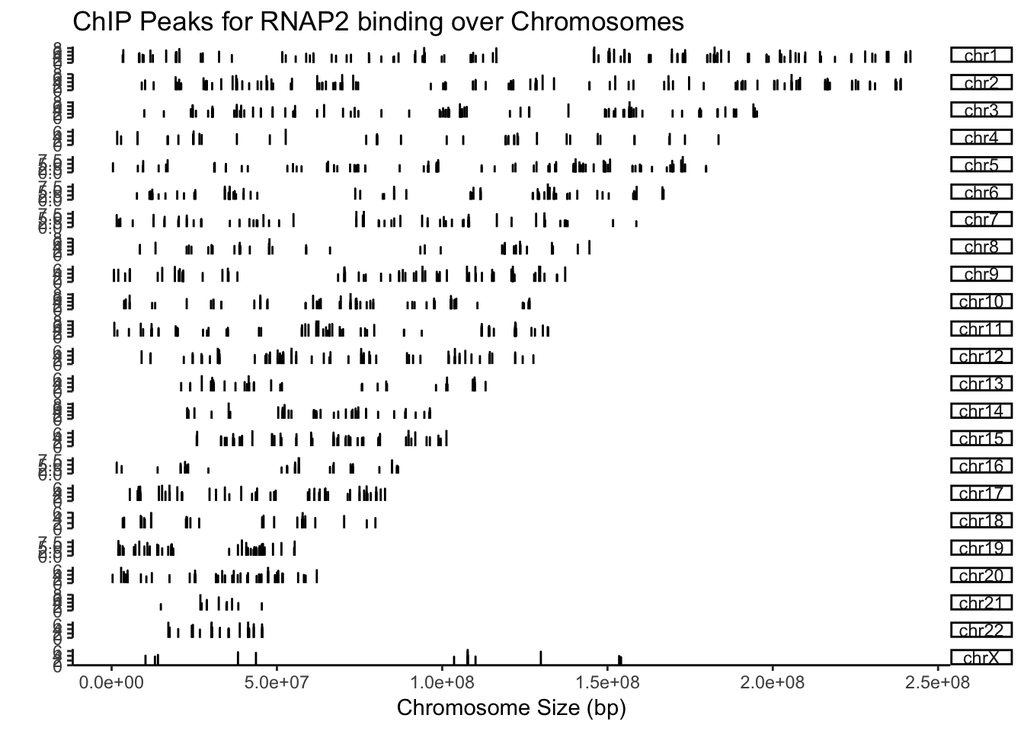

#### ANNOTATION OF ENRICHED REGIONS IN THE DATASET

Peak Annotation is performed by annotatePeak where by default TSS(transcription start site) is defined from -3kb to +3kb. The output of annotatePeak is a csAnno instance. ChIPseeker provides as.GRanges to convert csAnno to GRanges instance, and as.data.frame to convert csAnno to data.frame which can be exported to file by write.table.TxDb object contained transcript-related features of a particular genome.

The genomic region of the peak is reported in the annotation column where the regions are defined as: * Promoter * 5’ UTR * 3’ UTR * Exon * Intron * Downstream * Intergenic

Annotation of Peaks for Condition 1: GR binding

```
## >> loading peak file...               2018-07-30 13:32:50
## >> preparing features information...      2018-07-30 13:32:50
## >> identifying nearest features...        2018-07-30 13:32:53
## >> calculating distance from peak to TSS...   2018-07-30 13:32:54
## >> assigning genomic annotation...        2018-07-30 13:32:54
## >> adding gene annotation...          2018-07-30 13:33:29
## >> assigning chromosome lengths           2018-07-30 13:33:29
## >> done...                    2018-07-30 13:33:29
```

```
##   seqnames     start       end width strand width.1 strand.1 Conc Conc_dex
## 1    chr11 114179230 114179729   500      *     501        * 9.44    10.41
## 2    chr10  74056315  74056814   500      *     501        * 9.12    10.07
## 3     chr2  20438534  20439033   500      *     501        * 8.74     9.67
## 4    chr11 114154444 114154943   500      *     501        * 8.78     9.71
## 5    chr17  59825483  59825982   500      *     501        * 8.69     9.61
## 6    chr19  18020243  18020742   500      *     501        * 8.44     9.39
##   Conc_control Fold   p.value       FDR
## 1         4.71 5.70 4.03e-119 3.30e-114
## 2         5.38 4.68 4.03e-111 1.65e-106
## 3         5.38 4.29  8.74e-93  2.39e-88
## 4         5.30 4.42  1.69e-91  3.47e-87
## 5         5.51 4.10  7.51e-83  1.23e-78
## 6         4.63 4.75  2.73e-82  3.74e-78
##                                   annotation geneChr geneStart   geneEnd
```

[output cut: 20 more lines]

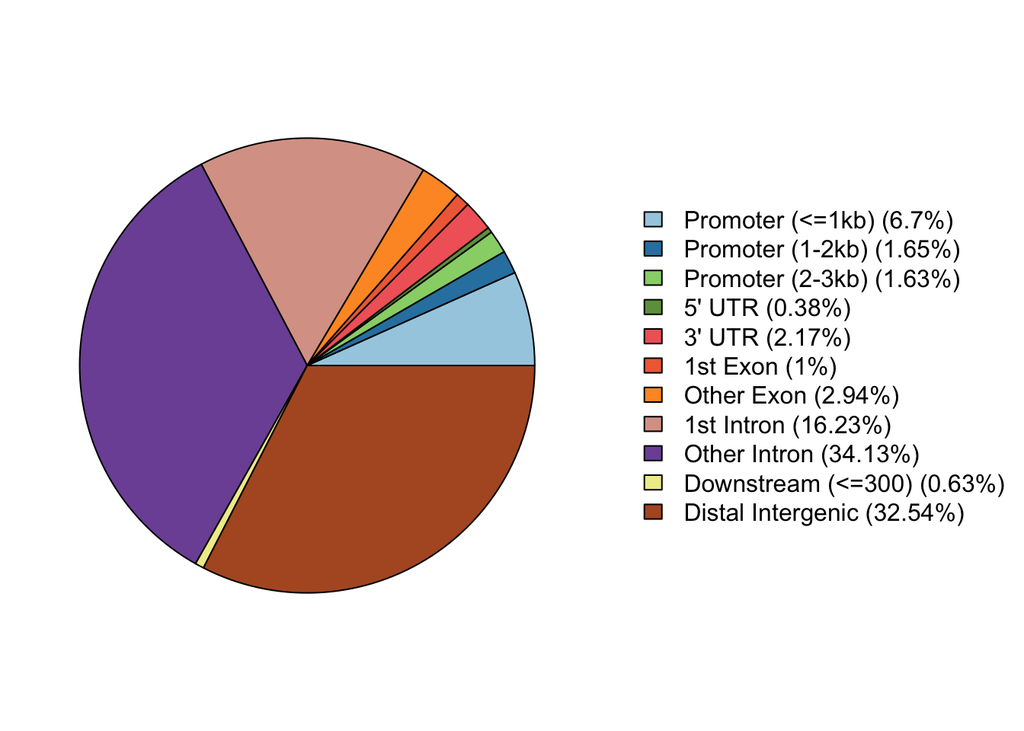

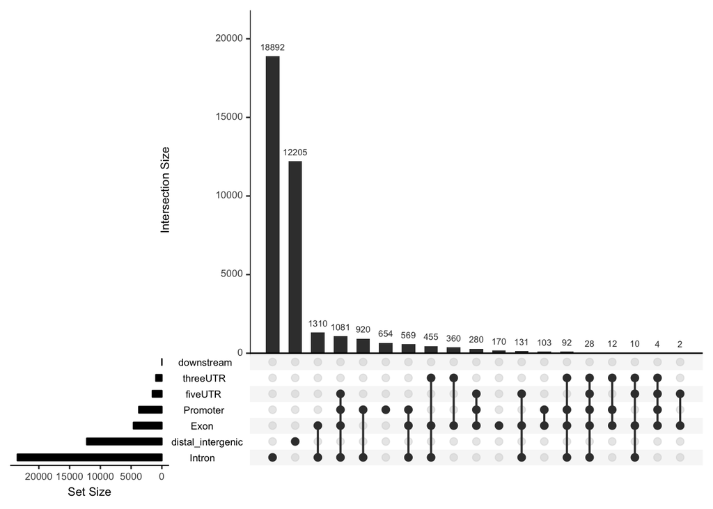

Annotation of Peak for Condition 2: RNAP2 binding

```
## >> loading peak file...               2018-07-30 13:33:31
## >> preparing features information...      2018-07-30 13:33:31
## >> identifying nearest features...        2018-07-30 13:33:31
## >> calculating distance from peak to TSS...   2018-07-30 13:33:32
## >> assigning genomic annotation...        2018-07-30 13:33:32
## >> adding gene annotation...          2018-07-30 13:33:35
## >> assigning chromosome lengths           2018-07-30 13:33:35
## >> done...                    2018-07-30 13:33:35
```

```
##   seqnames     start       end width strand width.1 strand.1 Conc Conc_dex
## 1    chr20  47318228  47318727   500      *     501        * 7.90     8.68
## 2    chr16  56608382  56608881   500      *     501        * 9.18     9.77
## 3    chr22  30246400  30246899   500      *     501        * 7.38     5.81
## 4    chr17   8152093   8152592   500      *     501        * 6.81     7.59
## 5     chr6  35727586  35728085   500      *     501        * 6.13     7.02
## 6     chr9 129320809 129321308   500      *     501        * 7.58     8.25
##   Conc_control  Fold  p.value      FDR       annotation geneChr geneStart
## 1         6.07  2.61 2.05e-37 5.42e-33 Promoter (<=1kb)      20  47318502
## 2         8.15  1.61 4.01e-25 5.29e-21 Promoter (<=1kb)      16  56608584
## 3         8.11 -2.30 4.86e-24 4.28e-20 Promoter (<=1kb)      22  30240447
## 4         4.99  2.60 2.25e-19 1.49e-15 Promoter (<=1kb)      17   8140472
## 5         3.37  3.64 4.41e-19 2.33e-15 Promoter (<=1kb)       6  35573585
## 6         6.32  1.93 5.73e-18 2.52e-14 Promoter (<=1kb)       9 129321016
##     geneEnd geneLength geneStrand    geneId transcriptId distanceToTSS
```

[output cut: 20 more lines]

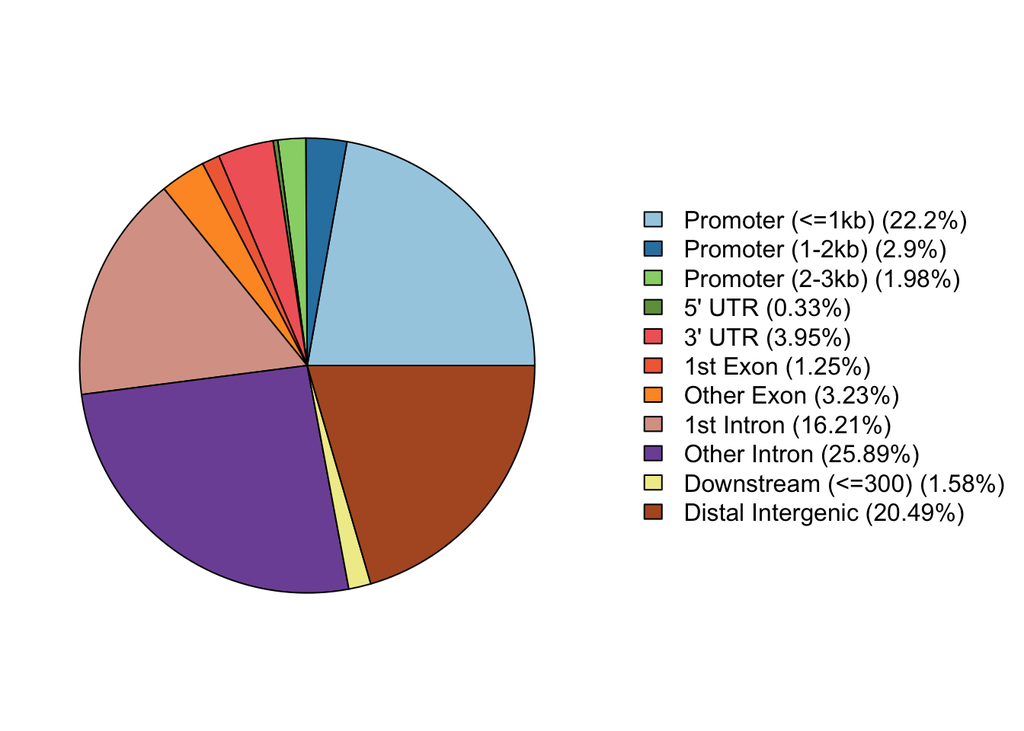

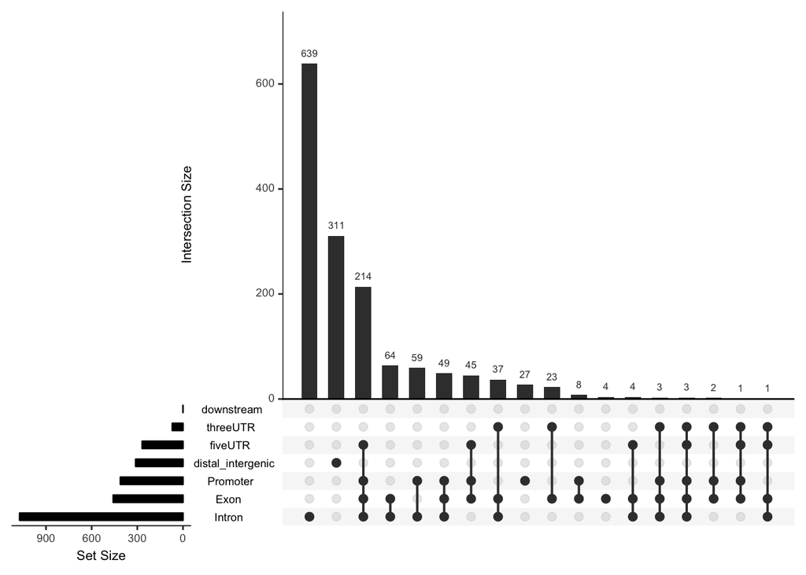

#### Functional enrichment analysis

Enrichment analysis is a widely used approach to identify biological themes and investigate whether the number of selected genes associated with a particular biological term is larger than expected, using packages like DOSE for Disease Ontology, ReactomePA for reactome pathway, clusterProfiler for Gene Ontology and KEGG enrichment analysis.

```
##                    ID                      Description GeneRatio   BgRatio
## GO:0034330 GO:0034330       cell junction organization  186/7271 270/17653
## GO:0034329 GO:0034329           cell junction assembly  156/7271 223/17653
## GO:0022604 GO:0022604 regulation of cell morphogenesis  285/7271 468/17653
## GO:0001501 GO:0001501      skeletal system development  297/7271 493/17653
## GO:0045216 GO:0045216  cell-cell junction organization  162/7271 238/17653
## GO:0001503 GO:0001503                     ossification  231/7271 371/17653
##                  pvalue     p.adjust       qvalue Count
## GO:0034330 1.888026e-20 1.172275e-16 8.060875e-17   186
## GO:0034329 2.305288e-18 5.519263e-15 3.795192e-15   156
## GO:0022604 2.666740e-18 5.519263e-15 3.795192e-15   285
## GO:0001501 4.498865e-18 6.983363e-15 4.801946e-15   297
## GO:0045216 3.293924e-17 4.090394e-14 2.812664e-14   162
## GO:0001503 1.179862e-16 1.220960e-13 8.395648e-14   231
```

```
##                    ID                                  Description
## GO:0030198 GO:0030198            extracellular matrix organization
## GO:0043062 GO:0043062         extracellular structure organization
## GO:1903391 GO:1903391 regulation of adherens junction organization
## GO:1901888 GO:1901888         regulation of cell junction assembly
## GO:0030335 GO:0030335        positive regulation of cell migration
## GO:0051893 GO:0051893        regulation of focal adhesion assembly
##            GeneRatio   BgRatio       pvalue     p.adjust       qvalue
## GO:0030198    51/787 341/17653 2.431727e-14 1.227293e-10 1.015438e-10
## GO:0043062    55/787 395/17653 4.961379e-14 1.252004e-10 1.035884e-10
## GO:1903391    17/787  57/17653 2.388959e-10 3.432174e-07 2.839714e-07
## GO:1901888    20/787  81/17653 2.720170e-10 3.432174e-07 2.839714e-07
## GO:0030335    54/787 486/17653 5.883778e-10 5.939085e-07 4.913883e-07
## GO:0051893    16/787  54/17653 9.015136e-10 6.499913e-07 5.377902e-07
##            Count
## GO:0030198    51
## GO:0043062    55
## GO:1903391    17
## GO:1901888    20
## GO:0030335    54
## GO:0051893    16
```

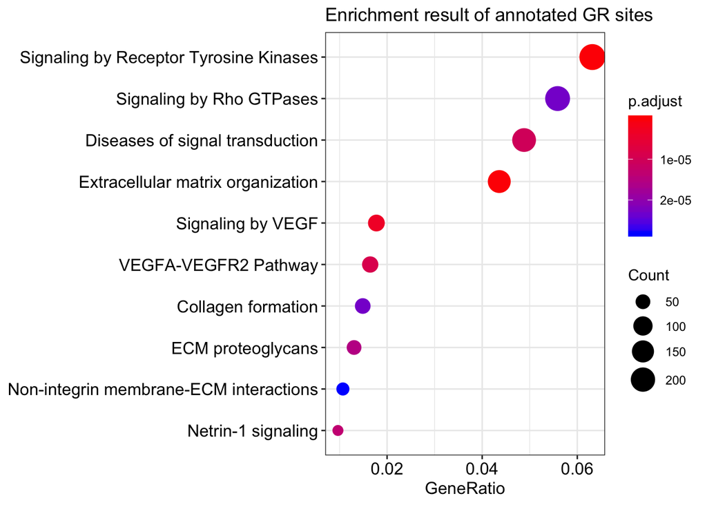

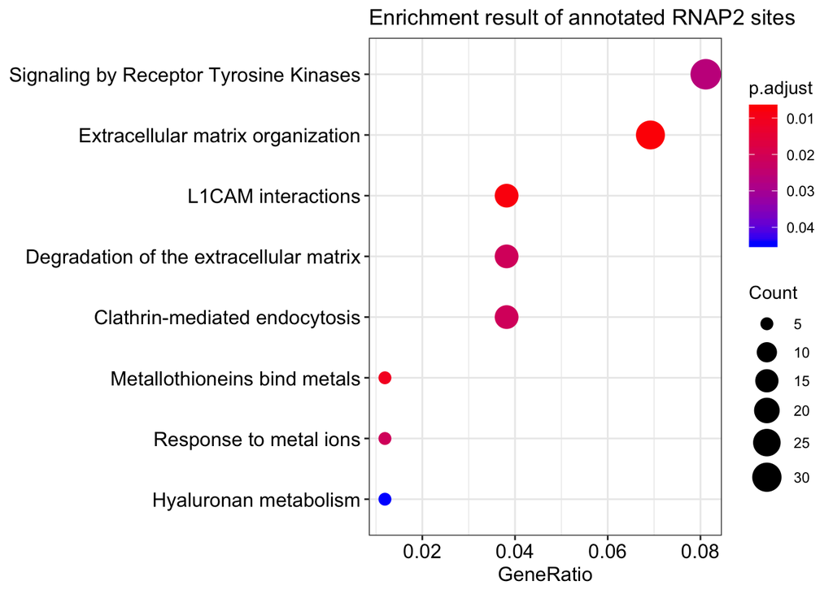

#### COMPARISON OF DIFFERENTIALLY BOUND ENRICHED SITES

This section compares annotations and distribution of peaks idenitfied in the two conditions. Input for this is both files together.

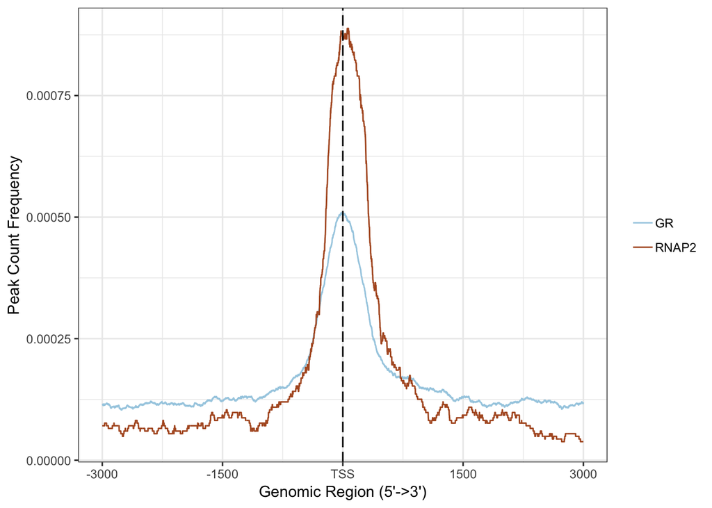

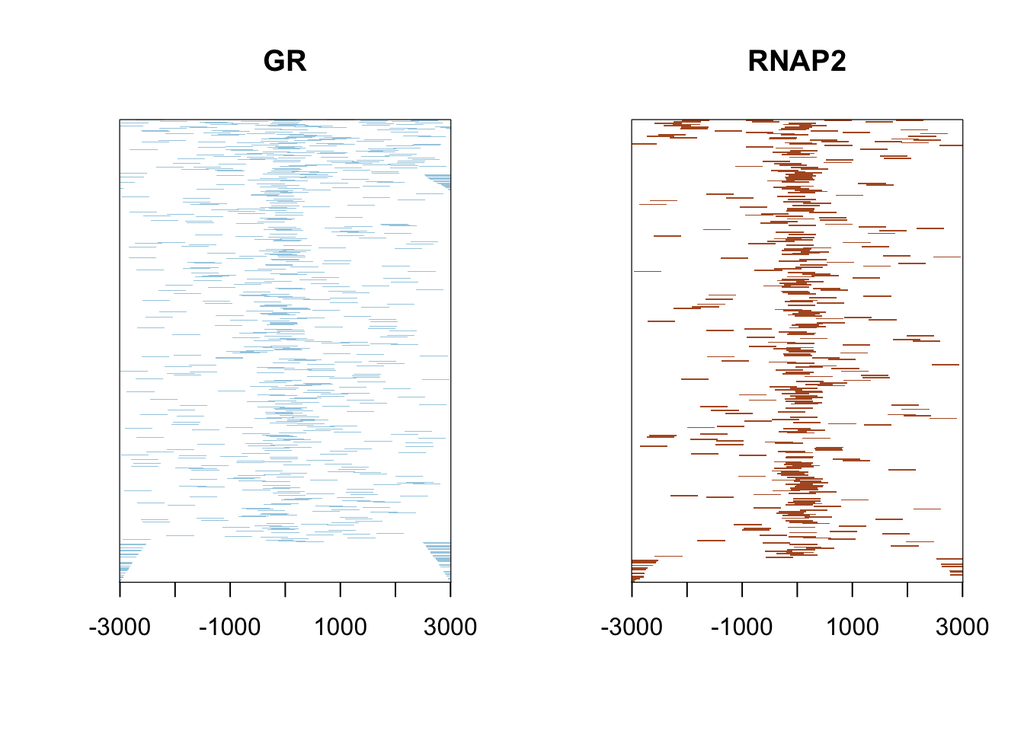

#### BARPLOTS

The first bar plot look at annotation differences in feature distribution of the two conditions where features include promotor regions, UTRs, exons, introns, and distal intergenic regions.

The second bar plot looks at percentage distribution of TF-binding loci position relative to TSS of the genes.

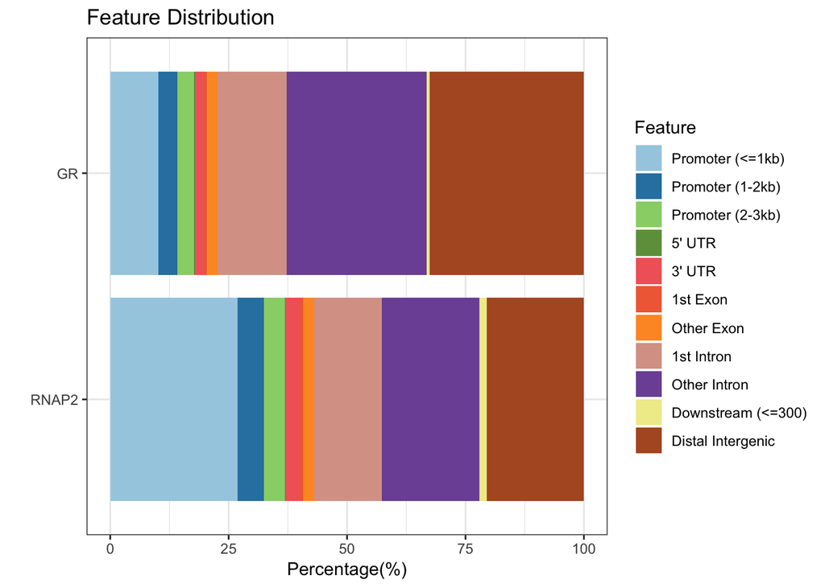

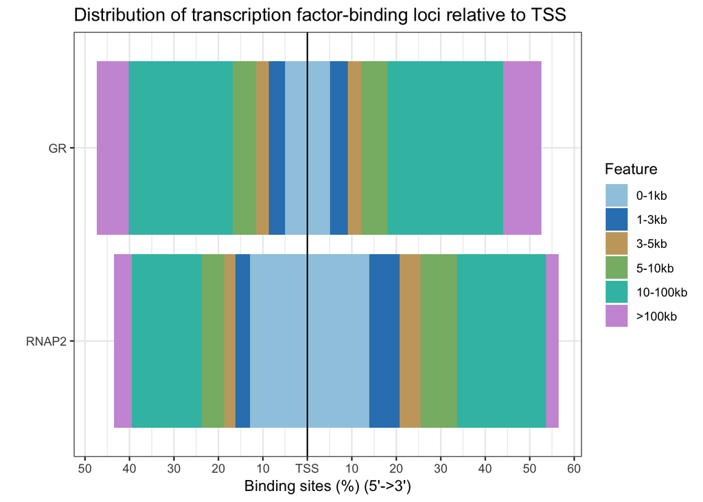

#### FUNCTIONAL PROFILE COMPARISON

This function is designed to link both coding and non-coding genomic regions to coding genes and facilitate functional analysis.

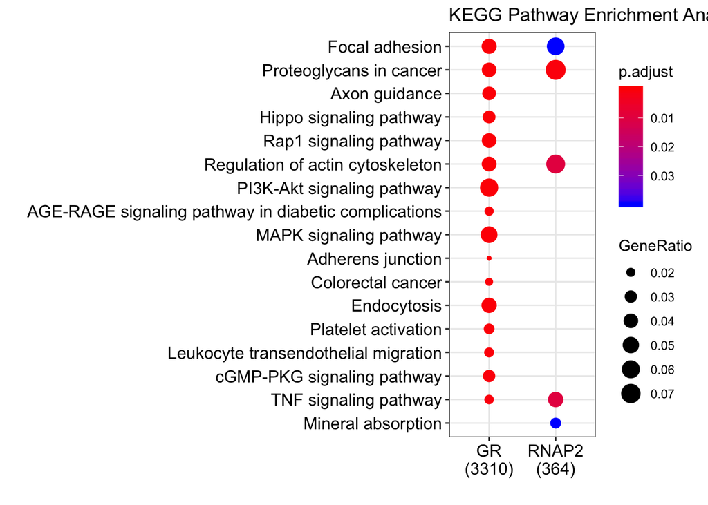

#### VENNPLOT

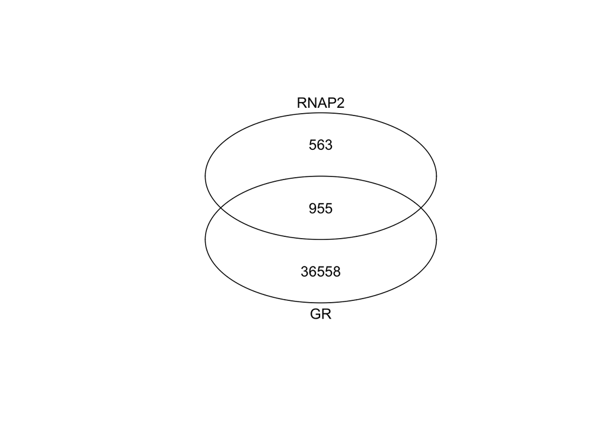

| Genes |
| --- |
| ZBTB16 |
| VCL |
| RHOB |
| VMP1 |
| ARRDC2 |
| LINC01714 |
| KLF9 |
| RIPOR2 |
| LTBP1 |
| FKBP5 |

[output cut: 945 more lines]

#### Session information

**R version 3.5.0 (2018-04-23)**

**Platform:** x86_64-apple-darwin15.6.0 (64-bit)

**locale:** en_US.UTF-8||en_US.UTF-8||en_US.UTF-8||C||en_US.UTF-8||en_US.UTF-8

**attached base packages:** *stats4*, *parallel*, *stats*, *graphics*, *grDevices*, *utils*, *datasets*, *methods* and *base*

**other attached packages:** *bindrcpp(v.0.2.2)*, *ReactomePA(v.1.24.0)*, *org.Hs.eg.db(v.3.6.0)*, *clusterProfiler(v.3.8.1)*, *TxDb.Hsapiens.UCSC.hg38.knownGene(v.3.4.0)*, *GenomicFeatures(v.1.32.0)*, *AnnotationDbi(v.1.42.1)*, *Biobase(v.2.40.0)*, *GenomicRanges(v.1.32.6)*, *GenomeInfoDb(v.1.16.0)*, *IRanges(v.2.14.10)*, *S4Vectors(v.0.18.3)*, *BiocGenerics(v.0.26.0)*, *DT(v.0.4)*, *ggplot2(v.3.0.0)*, *dplyr(v.0.7.6)*, *plyr(v.1.8.4)*, *pander(v.0.6.2)* and *ChIPseeker(v.1.16.1)*

**loaded via a namespace (and not attached):** *fgsea(v.1.6.0)*, *colorspace(v.1.3-2)*, *ggridges(v.0.5.0)*, *rprojroot(v.1.3-2)*, *qvalue(v.2.12.0)*, *XVector(v.0.20.0)*, *ggrepel(v.0.8.0)*, *bit64(v.0.9-7)*, *splines(v.3.5.0)*, *GOSemSim(v.2.6.0)*, *knitr(v.1.20)*, *jsonlite(v.1.5)*, *Rsamtools(v.1.32.2)*, *gridBase(v.0.4-7)*, *GO.db(v.3.6.0)*, *graph(v.1.58.0)*, *shiny(v.1.1.0)*, *ggforce(v.0.1.3)*, *graphite(v.1.26.1)*, *compiler(v.3.5.0)*, *httr(v.1.3.1)*, *rvcheck(v.0.1.0)*, *backports(v.1.1.2)*, *assertthat(v.0.2.0)*, *Matrix(v.1.2-14)*, *lazyeval(v.0.2.1)*, *TxDb.Hsapiens.UCSC.hg19.knownGene(v.3.2.2)*, *later(v.0.7.3)*, *tweenr(v.0.1.5)*, *htmltools(v.0.3.6)*, *prettyunits(v.1.0.2)*, *tools(v.3.5.0)*, *igraph(v.1.2.2)*, *gtable(v.0.2.0)*, *glue(v.1.3.0)*, *GenomeInfoDbData(v.1.1.0)*, *reshape2(v.1.4.3)*, *DO.db(v.2.9)*, *rappdirs(v.0.3.1)*, *fastmatch(v.1.1-0)*, *Rcpp(v.0.12.18)*, *enrichplot(v.1.0.2)*, *Biostrings(v.2.48.0)*, *gdata(v.2.18.0)*, *rtracklayer(v.1.40.3)*, *crosstalk(v.1.0.0)*, *ggraph(v.1.0.2)*, *stringr(v.1.3.1)*, *mime(v.0.5)*, *gtools(v.3.8.1)*, *XML(v.3.98-1.12)*, *DOSE(v.3.6.1)*, *zlibbioc(v.1.26.0)*, *MASS(v.7.3-50)*, *scales(v.0.5.0)*, *reactome.db(v.1.64.0)*, *promises(v.1.0.1)*, *hms(v.0.4.2)*, *SummarizedExperiment(v.1.10.1)*, *RColorBrewer(v.1.1-2)*, *yaml(v.2.2.0)*, *memoise(v.1.1.0)*, *gridExtra(v.2.3)*, *UpSetR(v.1.3.3)*, *biomaRt(v.2.36.1)*, *stringi(v.1.2.4)*, *RSQLite(v.2.1.1)*, *plotrix(v.3.7-2)*, *checkmate(v.1.8.5)*, *caTools(v.1.17.1.1)*, *boot(v.1.3-20)*, *BiocParallel(v.1.14.2)*, *rlang(v.0.2.1)*, *pkgconfig(v.2.0.1)*, *matrixStats(v.0.54.0)*, *bitops(v.1.0-6)*, *evaluate(v.0.11)*, *lattice(v.0.20-35)*, *purrr(v.0.2.5)*, *bindr(v.0.1.1)*, *labeling(v.0.3)*, *GenomicAlignments(v.1.16.0)*, *htmlwidgets(v.1.2)*, *cowplot(v.0.9.3)*, *bit(v.1.1-14)*, *tidyselect(v.0.2.4)*, *magrittr(v.1.5)*, *R6(v.2.2.2)*, *gplots(v.3.0.1)*, *DelayedArray(v.0.6.2)*, *DBI(v.1.0.0)*, *pillar(v.1.3.0)*, *withr(v.2.1.2)*, *units(v.0.6-0)*, *RCurl(v.1.95-4.11)*, *tibble(v.1.4.2)*, *crayon(v.1.3.4)*, *KernSmooth(v.2.23-15)*, *rmarkdown(v.1.10)*, *viridis(v.0.5.1)*, *progress(v.1.2.0)*, *grid(v.3.5.0)*, *data.table(v.1.11.4)*, *blob(v.1.1.1)*, *digest(v.0.6.15)*, *xtable(v.1.8-2)*, *httpuv(v.1.4.5)*, *tidyr(v.0.8.1)*, *munsell(v.0.5.0)* and *viridisLite(v.0.3.0)*